# Lab Chapter 9

### Testing 2 x 2 tables

Doll and Hill’s 1950 article studying the association between smoking and lung cancer contains one of the most important 2 x 2 tables in history.

Here’s their data:

```r
smoking <- as.table(rbind(c(688, 650), c(21, 59)))
dimnames(smoking) <- list(has.smoked = c("yes", "no"),
                    lung.cancer = c("yes","no"))
smoking
```

```
##           lung.cancer
## has.smoked yes  no
##        yes 688 650
##        no   21  59
```

**(a)** Use `fisher.test()` to test if there’s an association between smoking and lung cancer.

```r
# Edit me
smoking.fisher.test <- fisher.test(smoking)
smoking.fisher.test
```

```
##
##  Fisher's Exact Test for Count Data
##
## data:  smoking
## p-value = 1.476e-05
## alternative hypothesis: true odds ratio is not equal to 1
## 95 percent confidence interval:
##  1.755611 5.210711
## sample estimates:
## odds ratio
##   2.971634
```

**(b)** What is the odds ratio?

```r
smoking.fisher.test$estimate
```

```
## odds ratio
##   2.971634
```

**(c)** Are your findings significant?

```r
smoking.fisher.test$p.value
```

```
## [1] 1.476303e-05
```

### Plotting error bars

This exercise will take a long time if you choose to pursue it.

Using Doll and Hill’s smoking data and, construct a bar graph with accompanying error bars showing the proportion of study participants with lung cancer.

To succeed in this exercise, you’ll have to follow along careful with the lecture notes. Please read the section titled “Plotting the table values with confidence”.

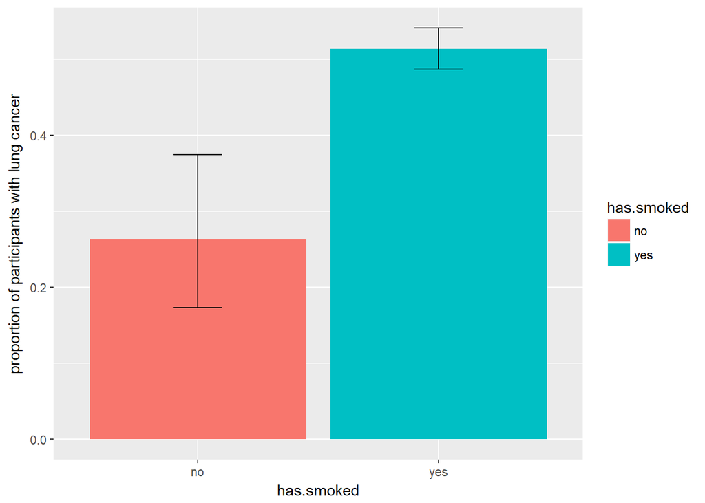

```r
# 'melt' table into a data frame
smoking.melt <- melt(smoking, id=c("lung.cancer", "has.smoked"))

# Add a row sums column giving denominators (# smoked, # not smoked) for proportions
smoking.melt <- transform(smoking.melt, totals = rowSums(smoking)[rev(has.smoked)])

# define list of prop, and lower and upper endpoints
conf.ints <- list(prop = NULL, lower = NULL, upper = NULL)
for(i in 1:nrow(smoking.melt)) {
  numerator <- smoking.melt$value[i]
  denominator <- smoking.melt$totals[i]
  prop.test.out <- prop.test(numerator, denominator)

  # Add estimate of proportion to list
  conf.ints[["prop"]][i] <- prop.test.out$estimate
  # Grab confidence interval
  interval <- prop.test.out$conf.int
  # Add estimate and endpoints to conf.ints list
  conf.ints[["lower"]][i] <- interval[1]
  conf.ints[["upper"]][i] <- interval[2]
}

# Append confidence interval information to melted data frame
smoking.toplot <- cbind(smoking.melt, conf.ints)

# Use ggplot to construct plot
ggplot(smoking.toplot[smoking.toplot$lung.cancer == "yes",], aes(x=has.smoked, y=prop, fill=has.smoked)) +
  geom_bar(position="dodge", stat="identity") +
  geom_errorbar(aes(ymin=lower, ymax=upper),
                width=.2,                    # Width of the error bars
                position=position_dodge(0.9)) +
  ylab("proportion of participants with lung cancer")
```

### ANOVA with birthwt data

Let’s form our favourite birthwt data set.

```r
# Rename the columns to have more descriptive names
colnames(birthwt) <- c("birthwt.below.2500", "mother.age", "mother.weight",
    "race", "mother.smokes", "previous.prem.labor", "hypertension", "uterine.irr",
    "physician.visits", "birthwt.grams")

# Transform variables to factors with descriptive levels
birthwt <- transform(birthwt,
            race = as.factor(mapvalues(race, c(1, 2, 3),
                              c("white","black", "other"))),
            mother.smokes = as.factor(mapvalues(mother.smokes,
                              c(0,1), c("no", "yes"))),
            hypertension = as.factor(mapvalues(hypertension,
                              c(0,1), c("no", "yes"))),
            uterine.irr = as.factor(mapvalues(uterine.irr,
                              c(0,1), c("no", "yes")))
            )
```

```r
phys.visit.binned <- birthwt$physician.visits
phys.visit.binned[phys.visit.binned >= 3] <- "3.or.more"
birthwt <- transform(birthwt, phys.visit.binned = as.factor(phys.visit.binned))

birthwt$phys.visit.binned
```

```
##   [1] 0         3.or.more 1         2         0         0         1
##   [8] 1         1         0         0         1         0         2
##  [15] 0         0         0         3.or.more 0         1         2
##  [22] 3.or.more 1         0         2         0         0         2
##  [29] 0         1         1         1         1         1         0
##  [36] 2         2         0         2         1         2         2
##  [43] 1         0         0         0         3.or.more 0         2
##  [50] 0         1         0         0         2         0         0
##  [57] 0         0         0         0         0         2         0
##  [64] 0         0         1         2         3.or.more 1         2
##  [71] 0         2         1         0         0         0         1
##  [78] 3.or.more 0         0         1         0         0         0
##  [85] 0         0         0         0         0         1         0
##  [92] 2         0         0         0         1         1         0
##  [99] 0         1         1         0         0         1         0
## [106] 0         1         0         2         3.or.more 2         1
## [113] 2         1         0         1         0         0         2
## [120] 1         1         0         1         0         2         2
## [127] 1         0         1         1         0         2         0
## [134] 0         0         0         1         1         0         1
## [141] 0         0         0         1         0         2         2
## [148] 0         0         0         1         2         0         0
## [155] 0         0         3.or.more 1         0         0         0
## [162] 1         0         0         0         0         3.or.more 0
## [169] 1         0         1         0         0         0         0
## [176] 0         1         3.or.more 0         2         1         3.or.more
## [183] 0         0         2         2         0         0         3.or.more
## Levels: 0 1 2 3.or.more
```

[output not shown]

[output not shown]

The p-value is greater than 0.05, so the variation in birthweight across number of physician visits is not statistically significant.